# Bi623_QAA_EWong_Report_20230915

2023-09-12

## Bi623 QAA Report

Assigned reads:

28_4D_mbnl_S20_L008 3_2B_control_S3_L008

## QAA Pt 1-Read quality score distributions

Description:

Plots included for part 1 of QAA include: FastQC Plots, per-base quality score distributions for R1 and R2 reads, per-base N content, and plots produced from Demultiplexing.

Path to FastQC plotting script: https://github.com/evelyn-n-wong/QAA/blob/master/fastqc_plot_script_pt1.sh

For the python script that demultiplex_comparison.sh (path: pt1_output/demultiplex_output/demultiplex_comparison.sh) references on GitHub, see: https://github.com/evelyn-n-wong/Demultiplex/tree/master/Assignment-the-first/Part_1/Bi622_Pt1_Qscore_Dist.py

1. FastQC output plots:

28_4D_mbnl_S20_L008_R1_001

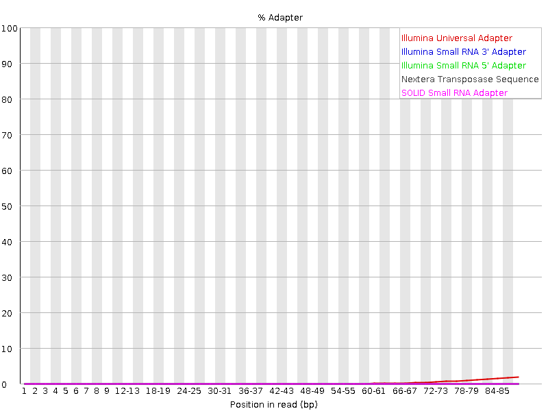

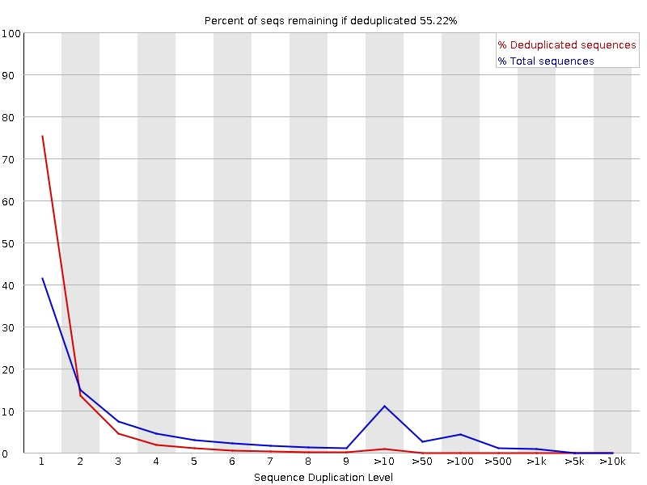

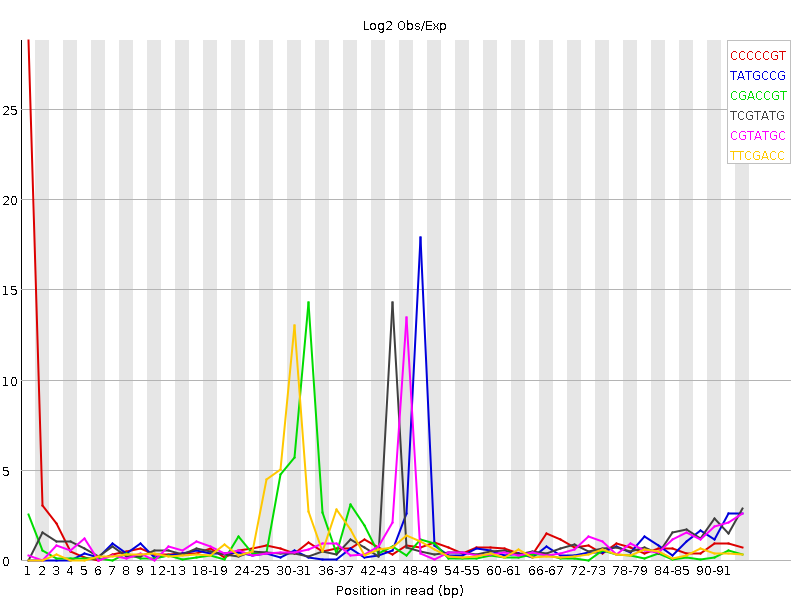

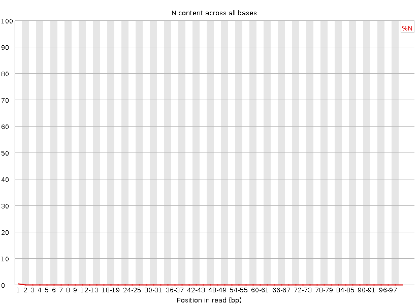

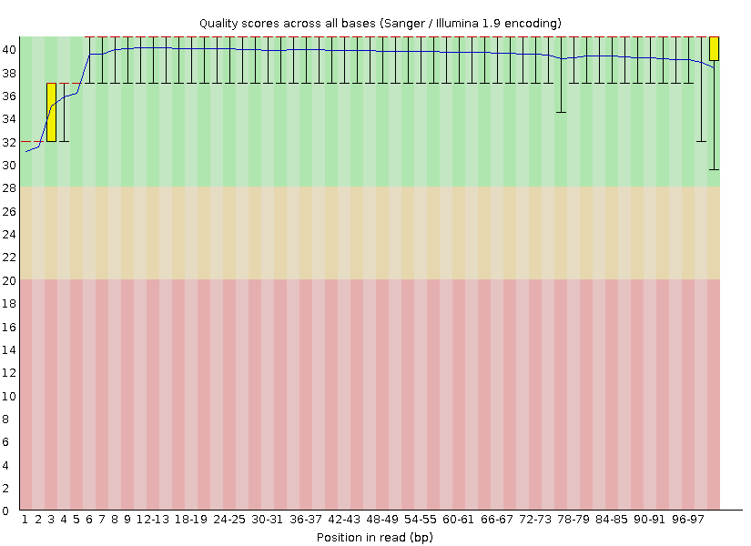

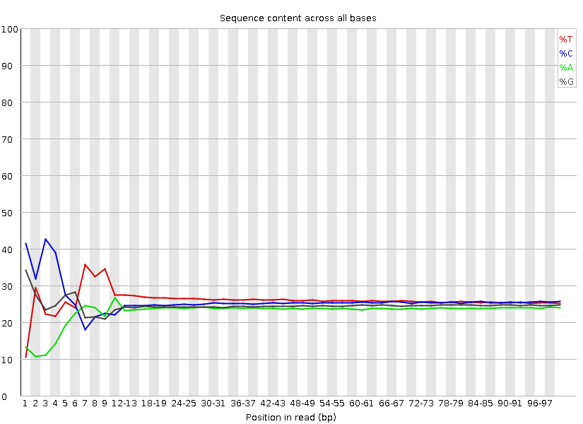

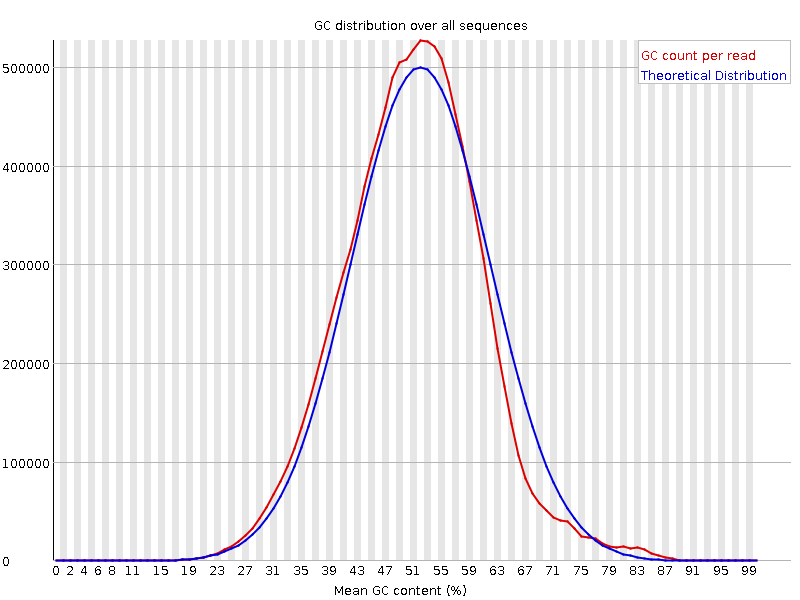

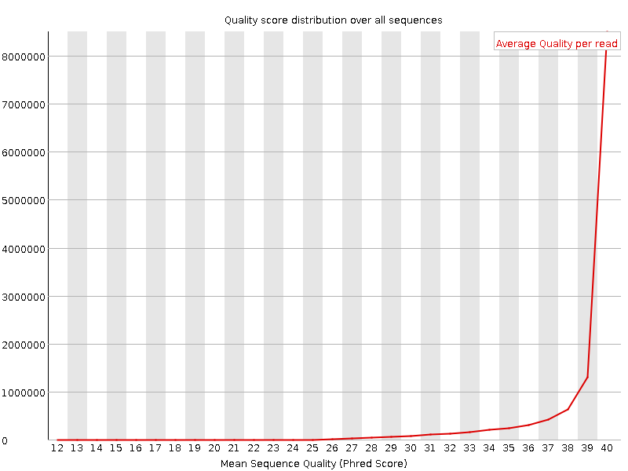

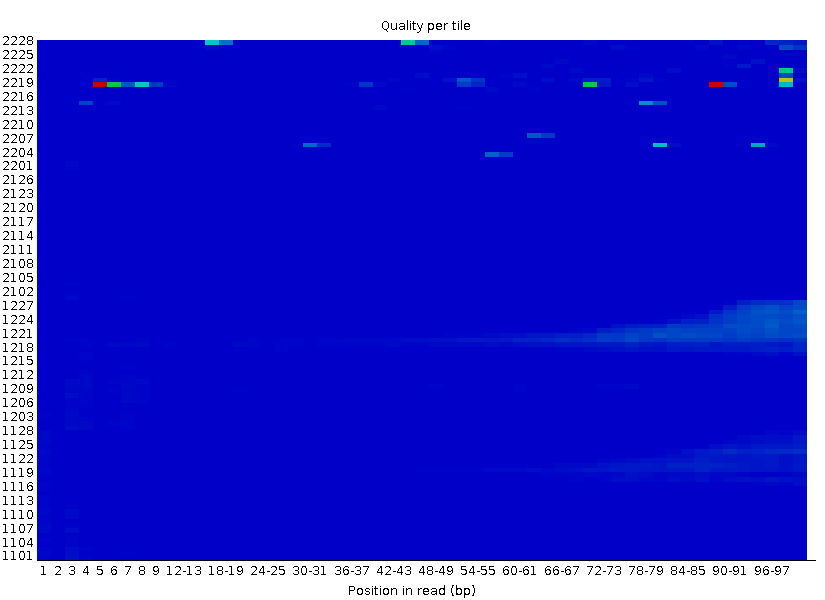

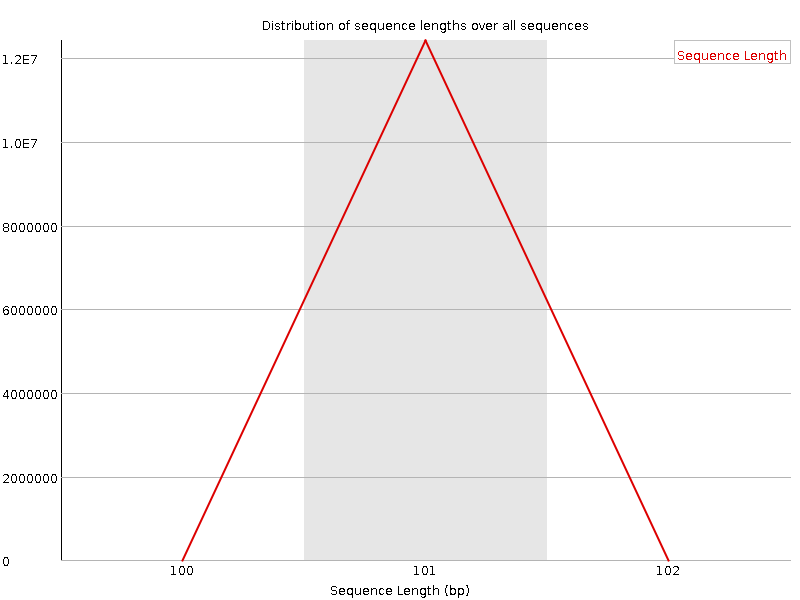

28_4D_mbnl_S20_L008_R2_001

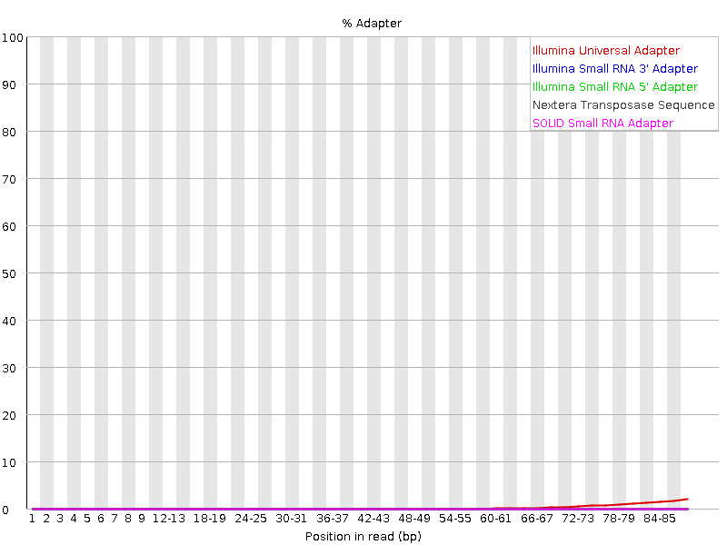

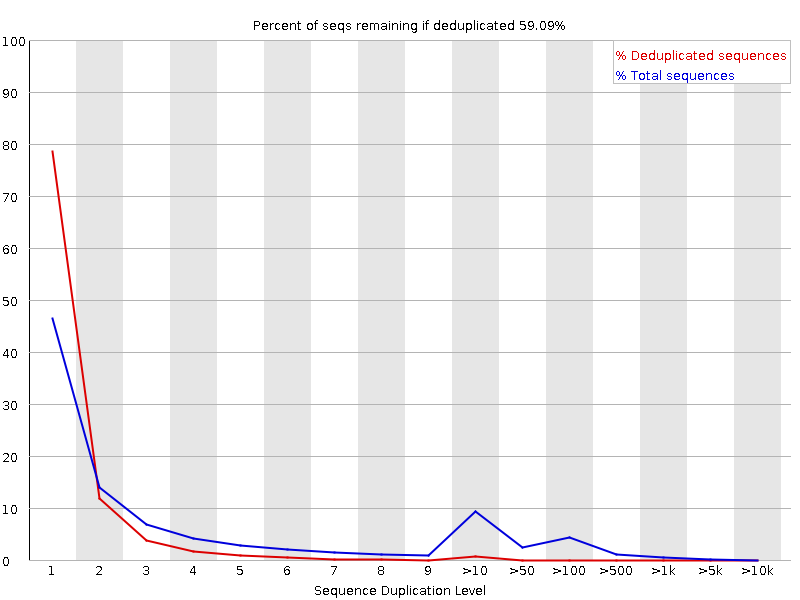

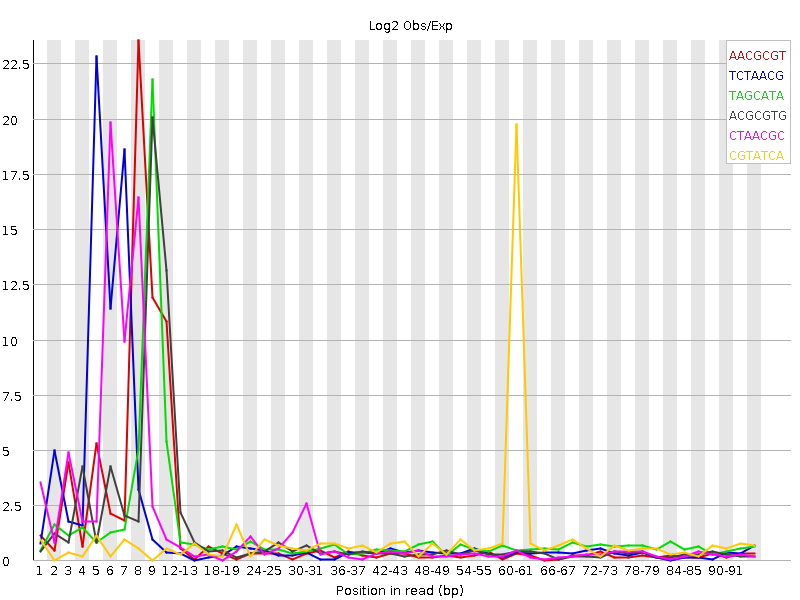

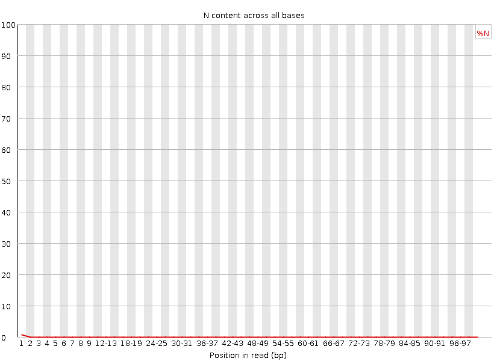

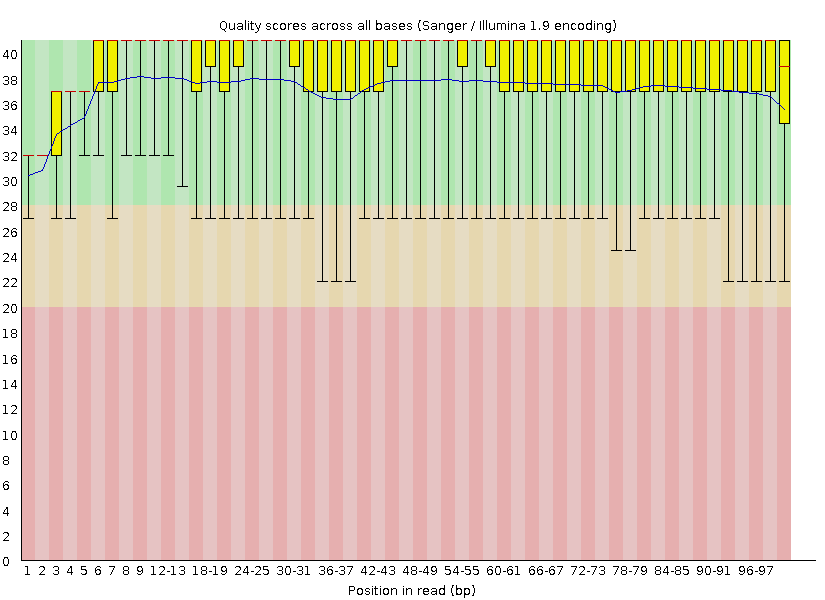

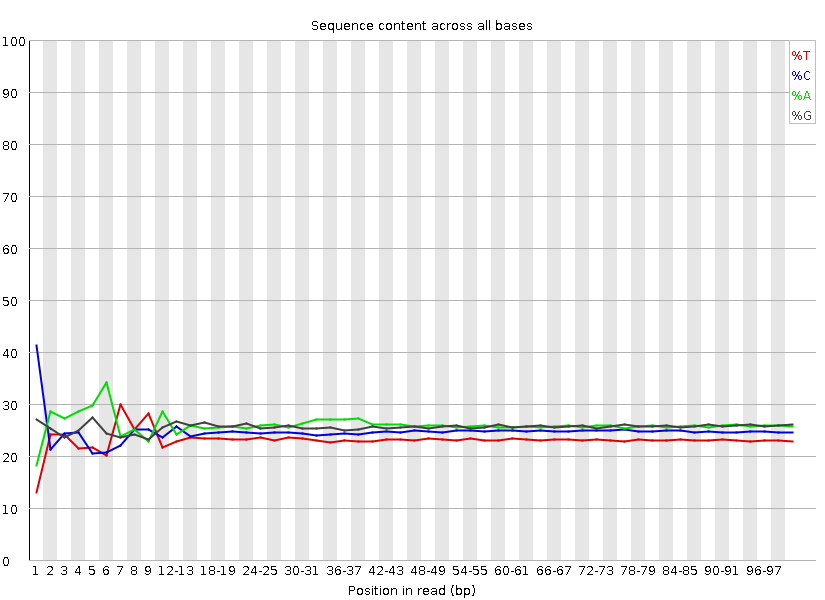

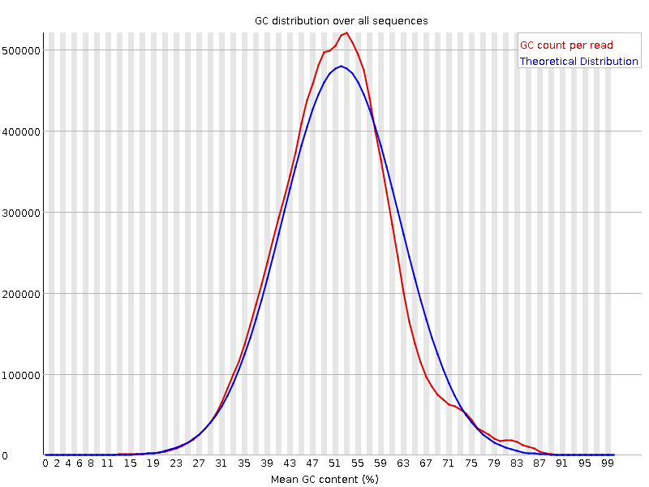

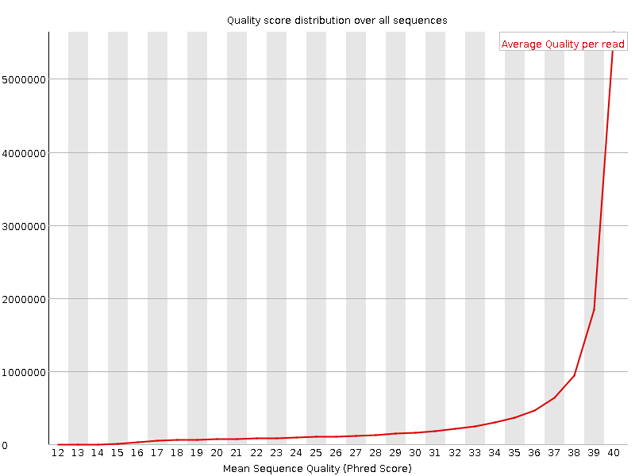

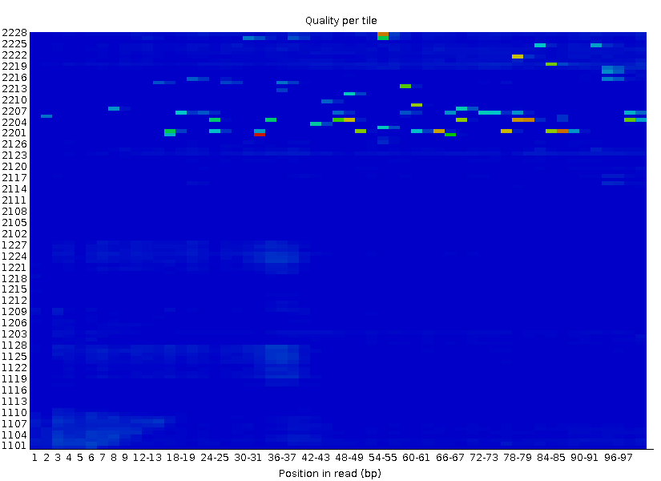

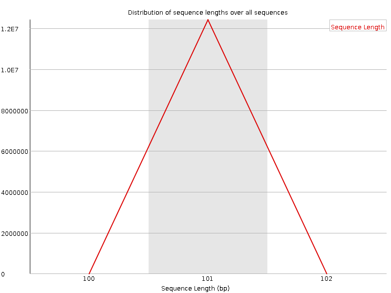

3_2B_control_S3_L008_R1_001

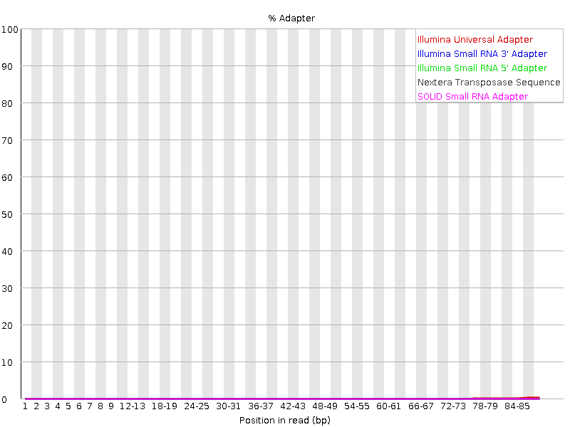

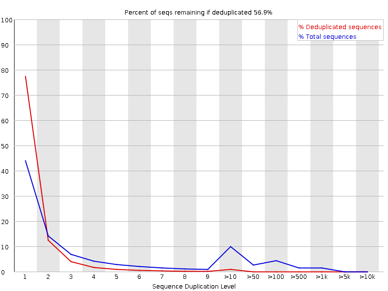

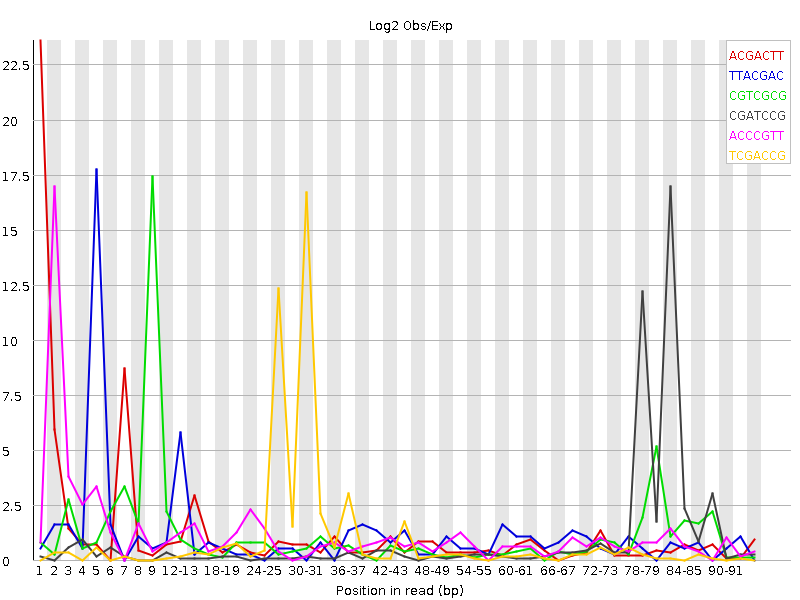

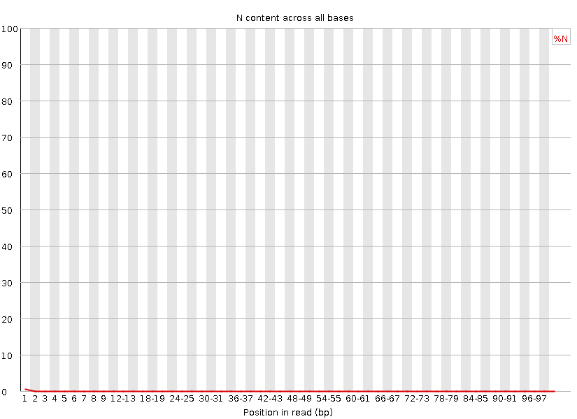

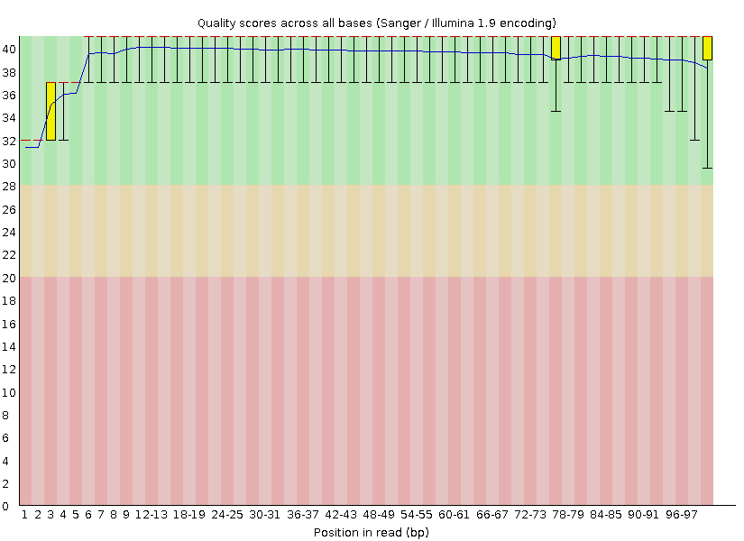

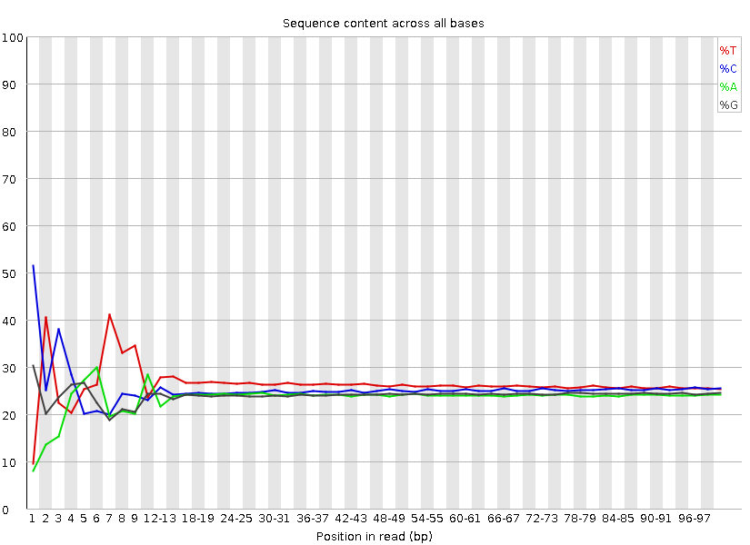

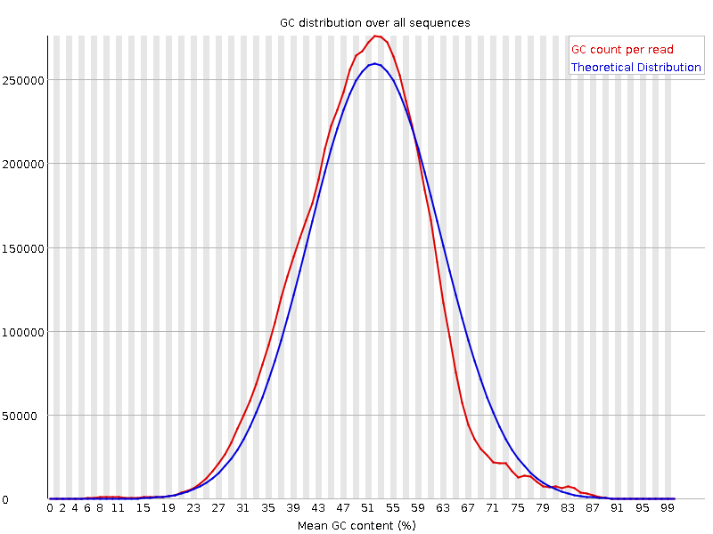

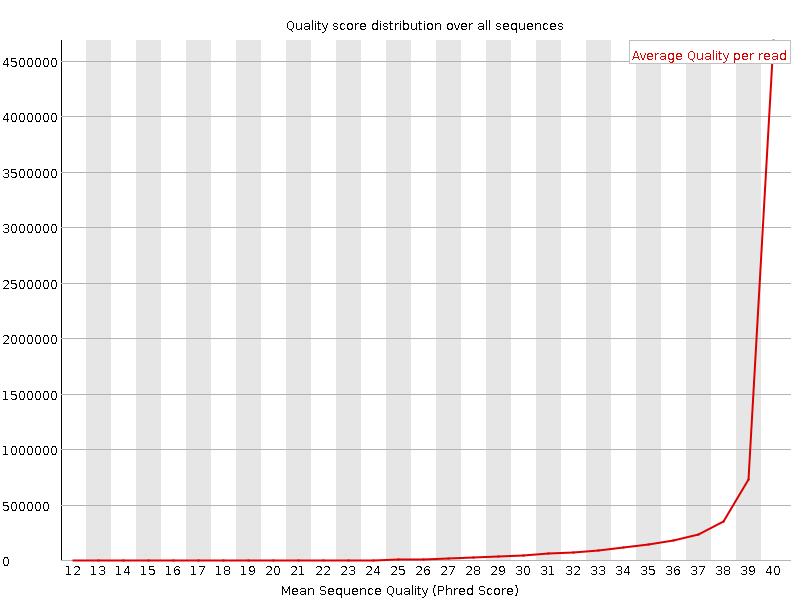